# Lab 6: Ordinal Logistic Regression with the Big Five

Author

Ching-Yi Cheng

Published

November 20, 2026

# Introduction

This lab examines whether people with higher Extraversion scores are more likely to endorse the Big Five item “Know how to comfort others” (A3). I expected a positive association because more outgoing people may have more opportunities to respond to others’ distress, which could be associated with greater confidence in knowing how to comfort someone. Because the item has ordered response categories, I used a cumulative logit model to estimate how the distribution of responses varies with Extraversion.

# Workflow

**1.** Score the Big Five subscales, prepare A3 as an ordered outcome, and centre Extraversion in the analysis sample. **2.** Describe the A3 responses and calculate the observed cumulative probabilities, odds, and log-odds. **3.** Fit and compare a threshold-only model and a model with Extraversion, then check the proportional-odds assumption. **4.** Interpret the shared odds ratio and visualize predicted response probabilities across the observed range of Extraversion.

# Research Question and Prediction

**Question.** Is Extraversion associated with higher endorsement of “Know how to comfort others”? **Prediction.** I expect people with higher Extraversion scores to be more likely to endorse the item. People who are more socially outgoing may have more opportunities to respond to others’ distress, which could be associated with greater confidence in knowing how to comfort someone.

# Dataset

**Note** The bfi data set and items should not be confused with the BFI (Big Five Inventory) of Oliver John and colleagues (John, O. P., Donahue, E. M., & Kentle, R. L. (1991). The Big Five Inventory–Versions 4a and 54. Berkeley, CA: University of California,Berkeley, Institute of Personality and Social Research.)

**Source** The items are from the ipip (Goldberg, 1999). The data are from the SAPA project (Revelle, Wilt and Rosenthal, 2010) , collected Spring, 2010 ( https://www.sapa-project.org/). https://search.r-project.org/CRAN/refmans/psych/html/bfi.html

# Part 1.Load packages and prepare the setup

The analysis included 2,694 participants. Extraversion was scored as the mean of its five items after reverse-scoring the first two items. The mean before centring was 4.14.

# Part 2. Examine the Outcomes

## 2.1 A3 Response Frequency Table

```r
a3_counts <- lab_data |>
  count(A3, .drop = FALSE) |>
  mutate(p = n / sum(n))

a3_counts |>
  gt() |>
  cols_label(A3 = "Response to A3", n = "Count", p = "Proportion") |>
  fmt_percent(columns = p, decimals = 1)
```

| Response to A3 | Count | Proportion |
| --- | --- | --- |
| Very inaccurate | 88 | 3.3% |
| Moderately inaccurate | 164 | 6.1% |
| Slightly inaccurate | 197 | 7.3% |
| Slightly accurate | 548 | 20.3% |
| Moderately accurate | 961 | 35.7% |
| Very accurate | 736 | 27.3% |

All response categories were represented and retained. The least frequent category was *Very inaccurate* (*n* = 88, 3.3%).

## 2.2 Bar Chart of A3 Responses

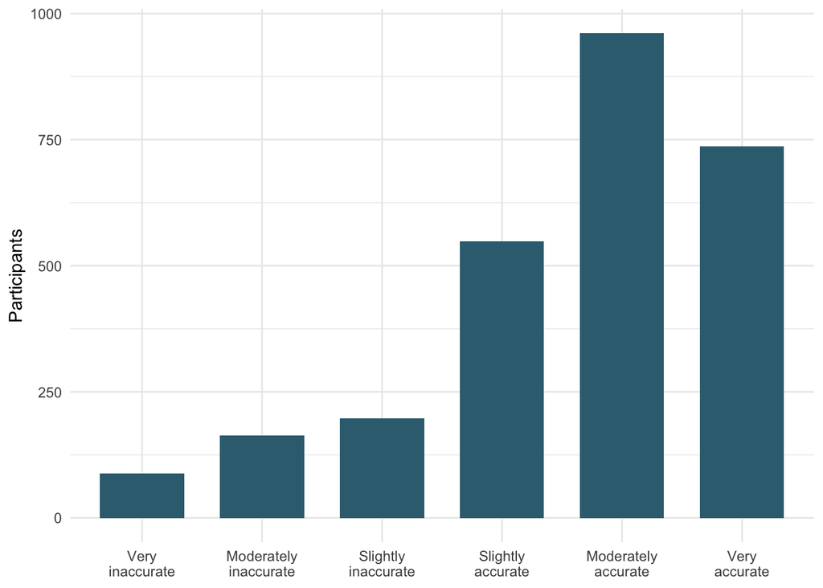

```r
ggplot(a3_counts, aes(A3, n)) +
  geom_col(fill = "#376D80", width = 0.7) +
  scale_x_discrete(labels = scales::label_wrap(13), drop = FALSE) +
  labs(x = NULL, y = "Participants") +
  theme_minimal()
```

Responses clustered toward the accurate end of the scale, with *Moderately accurate* as the most common response (35.7%).

## 2.3 Jittered Dot Plot of A3 Responses by Extraversion

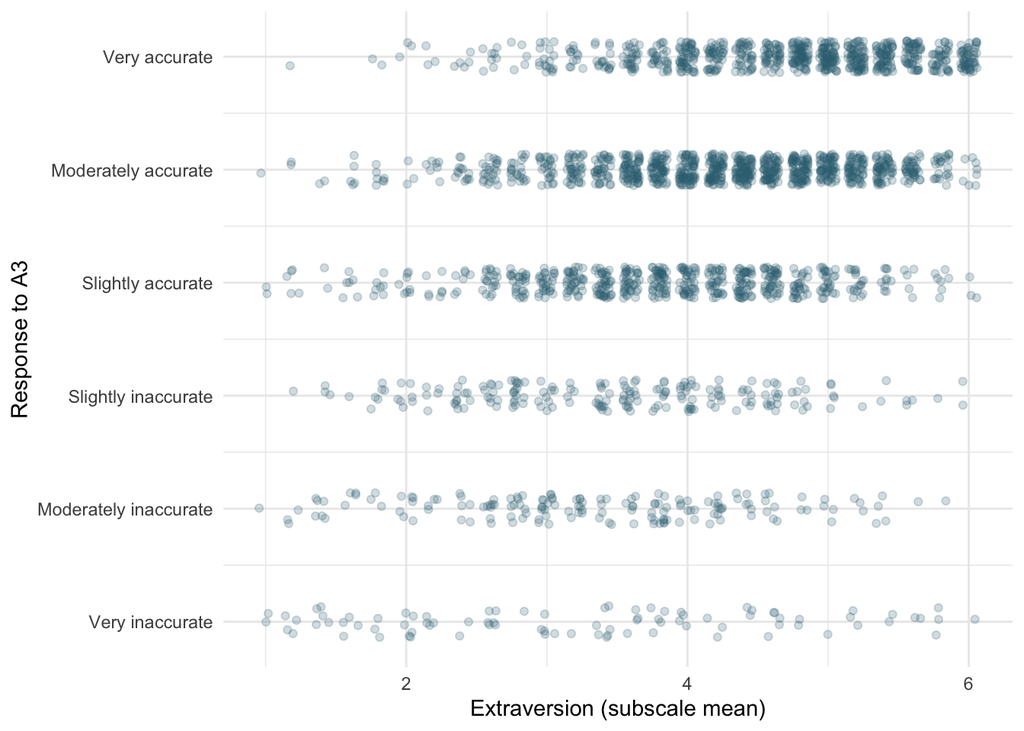

```r
ggplot(lab_data, aes(extra, as.integer(A3))) +
  geom_point(
    position = position_jitter(width = 0.06, height = 0.14, seed = 9041),
    alpha = 0.22, colour = "#376D80"
  ) +
  scale_y_continuous(breaks = 1:6, labels = response_levels) +
  labs(x = "Extraversion (subscale mean)", y = "Response to A3") +
  theme_minimal()
```

Each response falls into an ordered category, so the model estimates a probability for each of the six response options.

## 2.4 Bar Chart of Dominant Traits

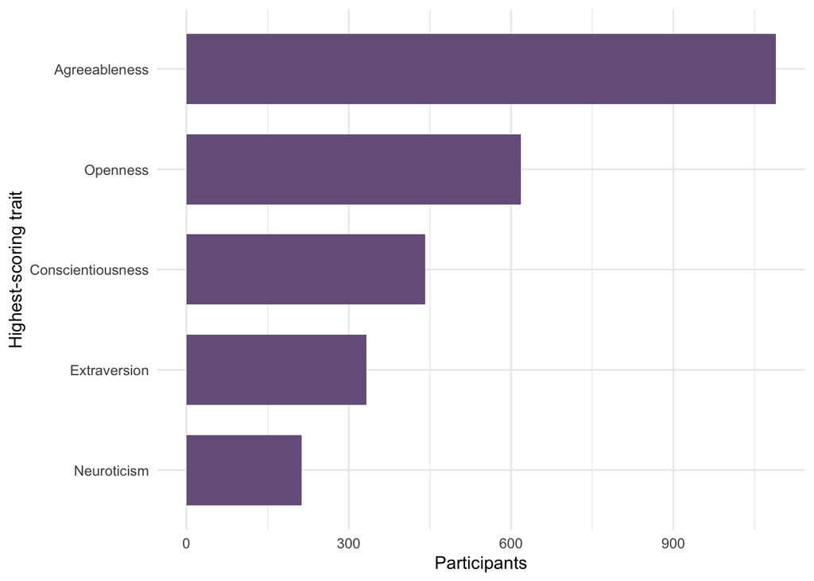

```r
lab_data |>
  count(dominant, .drop = FALSE) |>
  ggplot(aes(n, fct_reorder(dominant, n))) +
  geom_col(fill = "#77618A", width = 0.7) +
  labs(x = "Participants", y = "Highest-scoring trait") +
  theme_minimal()
```

```r
obs_tab <- a3_counts |>
  mutate(
    cumulative_p = cumsum(n) / sum(n),
    cumulative_odds = if_else(
      row_number() < n(), cumulative_p / (1 - cumulative_p), NA_real_
    ),
    cumulative_logit = if_else(
      row_number() < n(), qlogis(cumulative_p), NA_real_
    )
  )
```

Agreeableness was the most common highest-scoring trait, and Neuroticism was the least common. The bars are sorted by frequency, while the trait categories themselves have no inherent order.

# Part 3. Cumulative Probabilities

## 3.1 Observed Cumulative Probabilities, Odds, and Log-Odds

```r
obs_tab |>
  gt() |>
  cols_label(
    A3 = "Response to A3", n = "Count", p = "P(Y = j)",
    cumulative_p = "P(Y ≤ j)", cumulative_odds = "Odds of Y ≤ j",
    cumulative_logit = "Log-odds of Y ≤ j"
  ) |>
  fmt_number(columns = c(p, cumulative_p), decimals = 3) |>
  fmt_number(columns = c(cumulative_odds, cumulative_logit), decimals = 2) |>
  sub_missing(missing_text = "—")
```

| Response to A3 | Count | P(Y = j) | P(Y ≤ j) | Odds of Y ≤ j | Log-odds of Y ≤ j |
| --- | --- | --- | --- | --- | --- |
| Very inaccurate | 88 | 0.033 | 0.033 | 0.03 | −3.39 |
| Moderately inaccurate | 164 | 0.061 | 0.094 | 0.10 | −2.27 |
| Slightly inaccurate | 197 | 0.073 | 0.167 | 0.20 | −1.61 |
| Slightly accurate | 548 | 0.203 | 0.370 | 0.59 | −0.53 |
| Moderately accurate | 961 | 0.357 | 0.727 | 2.66 | 0.98 |
| Very accurate | 736 | 0.273 | 1.000 | — | — |

About 16.7% of participants selected *Slightly inaccurate* or a lower category. The six response categories yield five cumulative cutpoints because the last category includes everyone. The probability of responding above that category is zero, so its cumulative odds and log-odds have no finite value.

```r
stopifnot(all(a3_counts$n > 0))
m0 <- clm(A3 ~ 1, data = lab_data, link = "logit")
m1 <- clm(A3 ~ extra_c, data = lab_data, link = "logit")

summary(m1)
```

```
formula: A3 ~ extra_c
data:    lab_data

 link  threshold nobs logLik   AIC     niter max.grad cond.H
 logit flexible  2694 -3814.51 7641.02 5(0)  1.74e-08 2.0e+01

Coefficients:
        Estimate Std. Error z value Pr(>|z|)
extra_c  0.83589    0.03666    22.8   <2e-16 ***
---
Signif. codes:  0 '***' 0.001 '**' 0.01 '*' 0.05 '.' 0.1 ' ' 1

Threshold coefficients:
                                          Estimate Std. Error z value
Very inaccurate|Moderately inaccurate     -3.77030    0.11286  -33.41
Moderately inaccurate|Slightly inaccurate -2.58075    0.07114  -36.28
Slightly inaccurate|Slightly accurate     -1.84634    0.05617  -32.87
Slightly accurate|Moderately accurate     -0.60419    0.04274  -14.14
Moderately accurate|Very accurate          1.14590    0.04649   24.65
```

## 4.2 Interpret the Thresholds at Average Extraversion

```r
th <- m1$alpha
b <- coef(m1)[["extra_c"]]
cum_avg <- plogis(th)
cat_avg <- diff(c(0, cum_avg, 1))
endorse_avg <- 1 - cum_avg[3]

tibble(
  Response = response_levels,
  Threshold = c(unname(th), NA_real_),
  `P(Y ≤ j)` = c(unname(cum_avg), 1),
  `P(Y = j)` = cat_avg
) |>
  gt() |>
  fmt_number(columns = Threshold, decimals = 2) |>
  fmt_percent(columns = c(`P(Y ≤ j)`, `P(Y = j)`), decimals = 1) |>
  sub_missing(missing_text = "—")
```

| Response | Threshold | P(Y ≤ j) | P(Y = j) |
| --- | --- | --- | --- |
| Very inaccurate | −3.77 | 2.3% | 2.3% |
| Moderately inaccurate | −2.58 | 7.0% | 4.8% |
| Slightly inaccurate | −1.85 | 13.6% | 6.6% |
| Slightly accurate | −0.60 | 35.3% | 21.7% |
| Moderately accurate | 1.15 | 75.9% | 40.5% |
| Very accurate | — | 100.0% | 24.1% |

Centring sets zero to the sample mean of Extraversion, so the thresholds describe a participant with an average score. This changes the reference point and leaves the slope unchanged. At average Extraversion, the most likely response was *Moderately accurate* (40.5%), and the predicted probability of responding *Slightly accurate* or higher was 86.4%.

## 4.3 Compare M0 Thresholds with Observed Cumulative Log-Odds

```r
tibble(
  Cutpoint = names(m0$alpha),
  Observed_logit = head(obs_tab$cumulative_logit, -1),
  M0_threshold = unname(m0$alpha)
) |>
  gt() |>
  fmt_number(columns = c(Observed_logit, M0_threshold), decimals = 3)
```

| Cutpoint | Observed_logit | M0_threshold |
| --- | --- | --- |
| Very inaccurate\|Moderately inaccurate | −3.388 | −3.388 |
| Moderately inaccurate\|Slightly inaccurate | −2.271 | −2.271 |
| Slightly inaccurate\|Slightly accurate | −1.609 | −1.609 |
| Slightly accurate\|Moderately accurate | −0.532 | −0.532 |
| Moderately accurate\|Very accurate | 0.978 | 0.978 |

The M0 thresholds match the observed cumulative log-odds because M0 has no predictors and describes the overall response distribution. The M1 thresholds describe the predicted distribution at average Extraversion.

```r
lrt <- anova(m0, m1)
lrt
```

```
Likelihood ratio tests of cumulative link models:

   formula:     link: threshold:
m0 A3 ~ 1       logit flexible
m1 A3 ~ extra_c logit flexible

   no.par    AIC  logLik LR.stat df Pr(>Chisq)
m0      5 8197.4 -4093.7
m1      6 7641.0 -3814.5  558.33  1  < 2.2e-16 ***
---
Signif. codes:  0 '***' 0.001 '**' 0.01 '*' 0.05 '.' 0.1 ' ' 1
```

```r
lr_stat <- lrt$LR.stat[2]
lr_df <- lrt$df[2]
lr_p <- lrt$`Pr(>Chisq)`[2]
```

Adding Extraversion improved model fit relative to the threshold-only model, χ²(1) = 558.33, *p* < .001.

## 5.2 AIC Comparison and Model Selection

```r
lr_stat <- lrt$LR.stat[2]
lr_df <- lrt$df[2]
lr_p <- lrt$`Pr(>Chisq)`[2]
aic_difference <- abs(AIC(m0) - AIC(m1))

tibble(
  Model = c("M0: Thresholds only", "M1: Extraversion"),
  Parameters = c(length(coef(m0)), length(coef(m1))),
  `Log-likelihood` = c(as.numeric(logLik(m0)), as.numeric(logLik(m1))),
  AIC = c(AIC(m0), AIC(m1))
) |>
  mutate(`ΔAIC` = AIC - min(AIC)) |>
  gt() |>
  fmt_number(columns = c(`Log-likelihood`, AIC, `ΔAIC`), decimals = 2)
```

| Model | Parameters | Log-likelihood | AIC | ΔAIC |
| --- | --- | --- | --- | --- |
| M0: Thresholds only | 5 | −4,093.68 | 8,197.35 | 556.33 |
| M1: Extraversion | 6 | −3,814.51 | 7,641.02 | 0.00 |

M1 had a lower AIC than M0 (ΔAIC = 556.33). Both the likelihood-ratio test and AIC favoured M1, so I carried it forward to the proportional-odds check.

## 5.3 Interpret the Extraversion Slope on the Latent Scale

```r
middle_width <- mean(diff(th)[2:3])
fraction_of_middle_category <- abs(b) / middle_width
```

A one-point increase in Extraversion was associated with an upward shift of 0.84 units on the latent response scale. This shift was about 84.6% of the average width of the two middle response categories on that scale.